# Using Python for Pixel-Based Analysis

## Pearson Correlation Coefficient for Images

```r
#extract image from a different person in the dataset
X5 = X[101,:]
X5.shape
X6 = np.reshape(X5,(64, 64))
X6.shape

#plot 2D array as image with matplotlib.pyplot
plt.imshow(X6, cmap="gray")
plt.xticks(())
plt.yticks(())
plt.savefig("Olive3.png", bbox_inches='tight')

#Call up image and save as object 'img1'. Not necessary for correlation
img3 = plt.imread(r'C:\Users\Mark V. Brow\Desktop\PythonDir\Olive3.png')
```

Here is the image for that person:

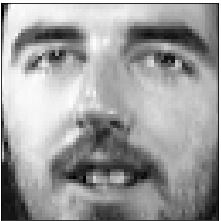

```r
#Now calculate Pearson correlation coefficient between both images from different people
corrIm = np.corrcoef(X2, X6)
corrImAbs = np.absolute(corrIm)
np.mean(corrImAbs)
np.max(corrImAbs)
np.median(corrImAbs)
# First quartile (Q1)
Q1 = np.percentile(corrImAbs, 25, interpolation = 'midpoint')
print(Q1)
# Third quartile (Q3)
Q3 = np.percentile(corrImAbs, 75, interpolation = 'midpoint')
print(Q3)
# Interquaritle range (IQR)
IQR = Q3 - Q1
print(IQR)
```

The mean Pearson correlation coefficient is **.42**, with the first quartile as **.16** and the third quartile as **.65**. We see a lower correlation between these images (even though the perspectives are the same) than between the images from the same person from different perspectives.

## Adding Filters

There is also a way of adding filters to the images in order to make features of the image more pronounced or distinct. Here we will scale the data from $0-1$ and create a binary filter.

```r
#scale data
X = np.asarray( X, 'float32')
X = (X - np.min(X, 0)) / (np.max(X, 0) + 0.0001)  # 0-1 scaling

# Convert image array to binary with threshold. This will create black-and-white images
X = X > 0.5
```

Here are the images with the filer:

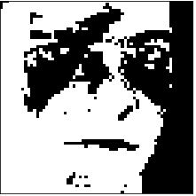

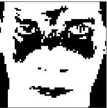

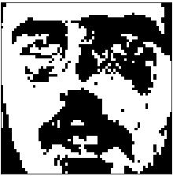

##### References

1. AT&T Laborties, Cambridge. (n.d.).